# NFL Passing Analysis

Tucker Morgan

1/9/2022

## Introduction

### Purpose

Teams in the National Football League (NFL) are racking up more passing yards than ever, so how can current quarterback (QB) passing stats be evaluated against historical data? This analysis will aim to answer that question and provide insight into how passing stats and QB performances have changed over the past 25 years.

I originally set out to analyze these data during my first semester at Columbia as I learned more R. Well, turns out we learned even more helpful material later in the semester, so I’m planning to run a re-vamped or “Reloaded” version now. I’m hoping to streamline some of my code from last time (for example, using `for` loops instead of copying code).

All of the data used in this analysis was obtained from https://www.pro-football-reference.com/.

### Motivation

A common theme over the past few years in NFL-commentary circles has been how to compare current NFL QB performances (particularly seasonal stat totals) to an historic benchmark. The game has changed in many ways from playstyle philosophies to major rule changes, so it’s a fair question: do higher stats (like yards or touchdowns) truly indicate better performing QBs or is it easier / more common to rack up stats in “today’s NFL”? A particular podcast highlighting this in my mind has been [The Ryen Russillo Podcast](https://www.theringer.com/ryen-russillo-podcast) from *The Ringer*. A common refrain has been something along the lines of “well, 4,000 yards ain’t what it used to be.” In a recent episode of another podcast at *The Ringer*, [The Bill Simmons Podcast](https://www.theringer.com/the-bill-simmons-podcast/2022/1/17/22887687/a-cowboys-pats-sadness-contest-apex-allen-boger-mania-and-round-2-lines-with-cousin-sal), the hosts discuss how Ben Roethlisberger’s recent statistical performance may overestimate the quality of his play in the 2021 season, citing the volume of passes in today’s NFL and changes in NFL rules.

I will first propose a simple measure to assess current performances against those of yesteryear. I will also analyze the distribution of passing yards over the years and see if classic benchmarks like 4,000 yards passing in a single season are as meaningful now as they were 25 years ago.

## Data Import and Cleaning

I want to first set up a function to load in and clean each yearly dataset.

```r
url <- "https://www.pro-football-reference.com/years/2021/passing.htm"
nfl_pass_html <- read_html(url)

nfl_pass_table <-
  nfl_pass_html %>%
  html_table() %>%
  first() %>%
  janitor::clean_names() %>%
  mutate(year = "2021")

rm(nfl_pass_html)
# Here I was able to successfully load in and extract the table from pro-football-reference;
# in my function, I will want to do this for each year and add a column for year. I think this can be incorporated into the function below.
```

```r
read_nfl_passing = function(url){

  html = read_html(url)

  pass_table = html %>%
    html_table() %>%
    first() %>%
    janitor::clean_names()

  output = pass_table

}
```

```r
nfl_passing <-
  tibble(
    season = 1995:2021,
    urls = str_c("https://www.pro-football-reference.com/years/", season, "/passing.htm")) %>%
  mutate(stats = map(urls, read_nfl_passing)) %>%
  unnest(cols = c(stats))
```

Nice! I was able to pull in several seasons of data from Pro Football Reference. It looks like there are a few columns I can remove to streamline the dataset from here, and I think the function pulled in the column headers for the additional pages of each year. I’ll go ahead and filter out the additional headers and unneeded columns. I will also need to convert the columns to numbers and factors accordingly, since all were considered characters because of the intermediary headers.

```r
nfl_passing_clean <-
  nfl_passing %>%
  filter(rk != "Rk") %>%
  select(-urls, -pos, -td_percent, -int_percent, -x1d, -lng, -y_c, -y_g, -rate, -sk, -yds_2, -sk_percent, -ny_a, -any_a, -x4qc, -gwd, -qbr) %>%
  rename(rank = rk, team = tm, games = g, starts = gs, record = q_brec, completions = cmp, attempts = att, yards = yds) %>%
  mutate(rank = as.numeric(rank),
         team = as.factor(team),
         age = as.numeric(age),
         games = as.numeric(games),
         starts = as.numeric(starts),
         completions = as.numeric(completions),
         attempts = as.numeric(attempts),
         cmp_percent = as.numeric(cmp_percent),
         yards = as.numeric(yards),
         td = as.numeric(td),
         int = as.numeric(int))
```

This data set includes every player to attempt a pass in each NFL season, however we are primarily interested in “the main guys” over the years. We’d like our data set to be indicative of QBs who are playing consistently from year to year - career QBs. First, let’s look at the distribution of yards and attempts.

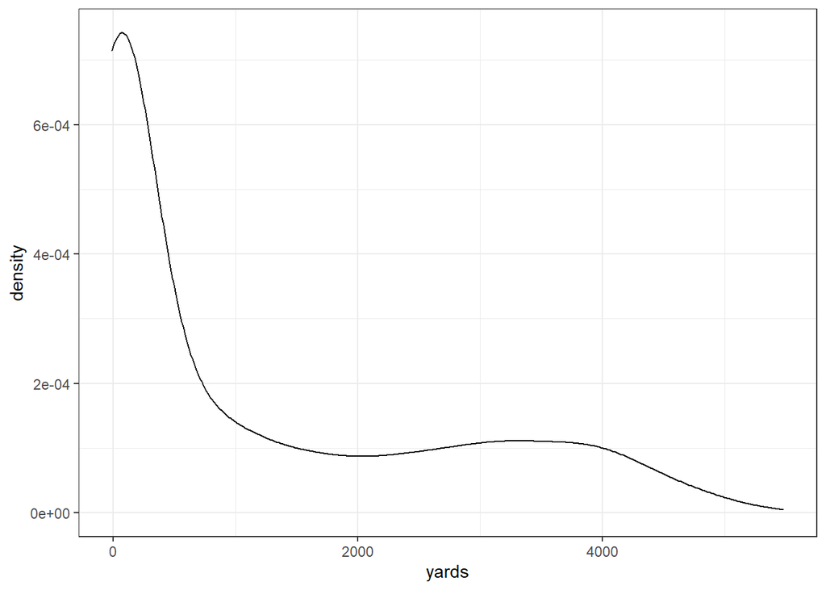

```r
nfl_passing_clean %>%
  ggplot(aes(x = yards)) +
  geom_density()
```

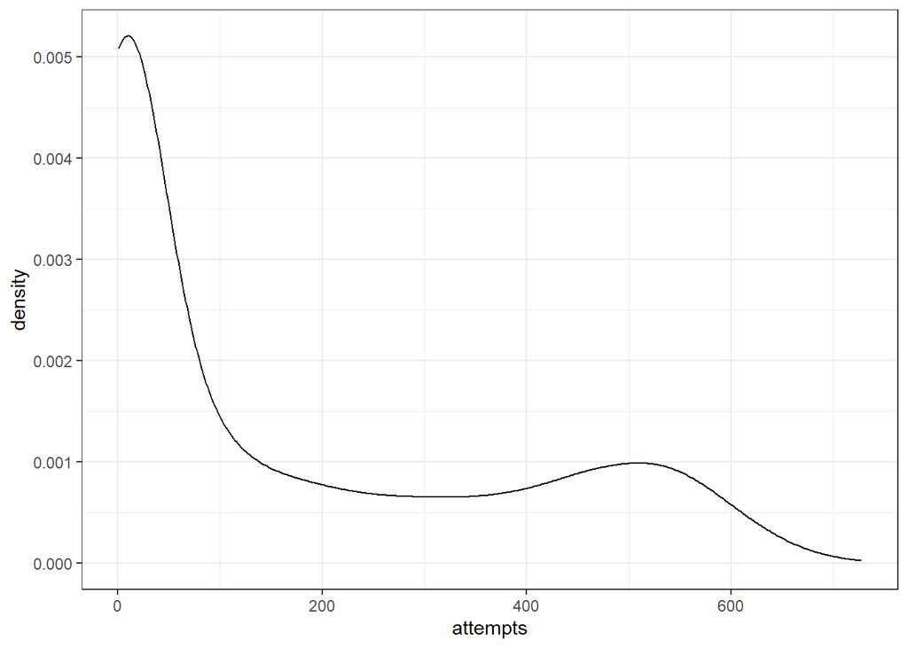

```r
nfl_passing_clean %>%
  ggplot(aes(x = attempts)) +
  geom_density()
```

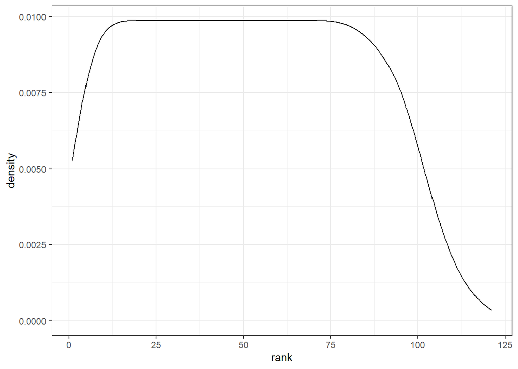

```r
nfl_passing_clean %>%
  ggplot(aes(x = rank)) +
  geom_density()
```

As expected, there are a large number of players with fewer than 1,000 or even 500 yards and a large number of players with fewer than 100 passing attempts. Since we’re interested in how performances change over time, we may want to be careful about our cut-off here. Setting a minimum yards or attempts cut-off could include more quarterbacks in future years compared to earlier years. In each season, Pro Football Reference has QBs ranked from 1 to n with n varying each year depending on how many players attempt a pass. I think setting a cut-off for `rank` might be the most consistent cut-off from year-to-year.

Although the number of NFL teams has changed over time with 30 teams in 1995 up to 32 teams from 2002 to present, the change in number of teams was relatively small (< 10% increase). Therefore, I will set the `rank` cutoff at 32 each year. This allows us to capture the QB seeing the most action for each NFL team with one or two additional quarterbacks in the 1995 to 2001 seasons.

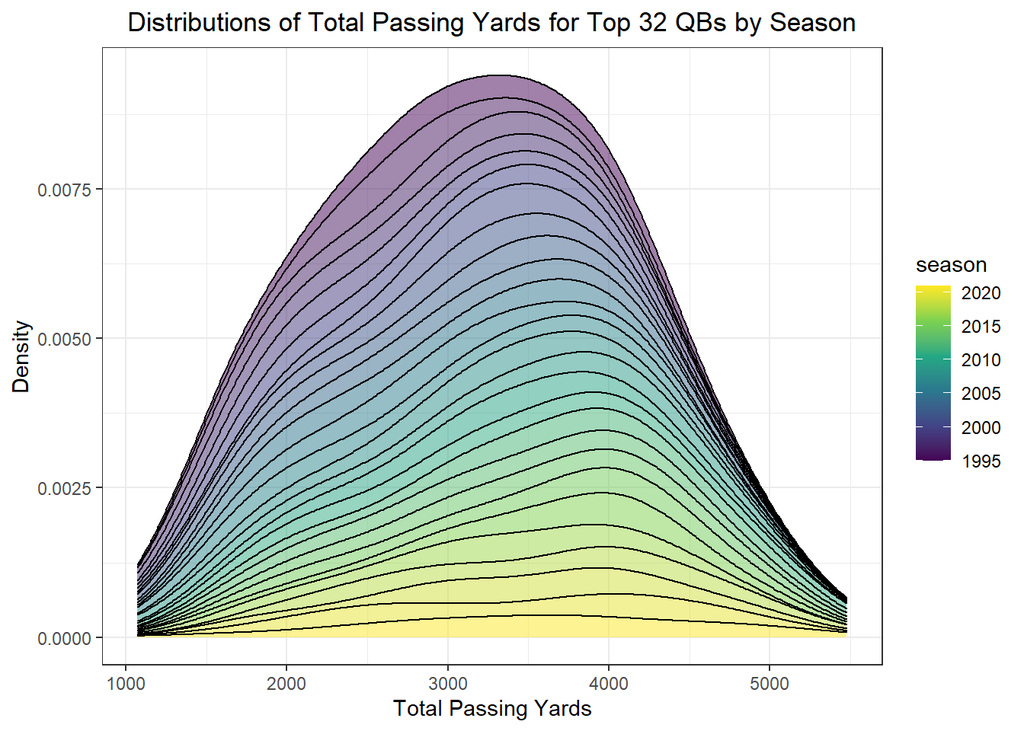

```r
nfl_passing_clean %>%
  filter(rank <= 32) %>%
  ggplot(aes(x = yards, group = season, fill = season)) +
  geom_density(alpha = 0.5, position = "stack") +
  theme(legend.position = "right") +
  labs(x = "Total Passing Yards", y = "Density", title = "Distributions of Total Passing Yards for Top 32 QBs by Season")
```

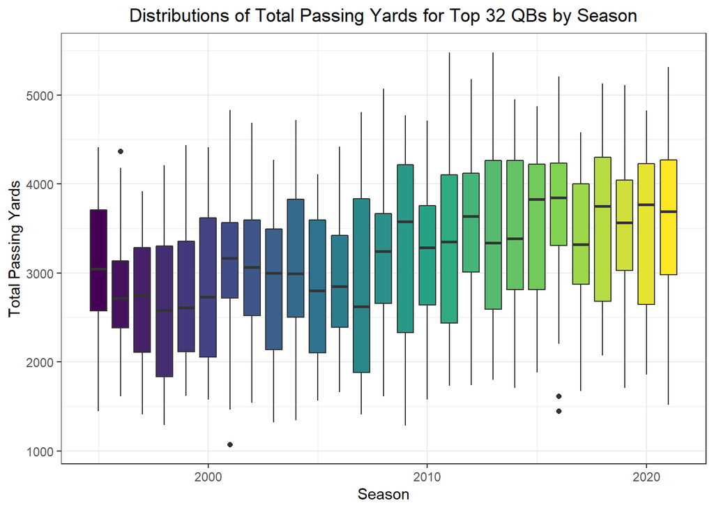

```r
nfl_passing_clean %>%
  filter(rank <= 32) %>%
  ggplot(aes(y = yards, x = season, group = season, fill = season)) +
  geom_boxplot() +
  theme(legend.position = "none") +
  labs(x = "Season", y = "Total Passing Yards", title = "Distributions of Total Passing Yards for Top 32 QBs by Season")
```

These two figures show that we’ve eliminated extreme skewness / outliers in most seasons by limiting the scope to the top 32 QBs. I think this will be an effective data set for our upcoming analysis.

## Analysis

### Anachronistic All-Stars: Performance Over Median (POM)

```r
nfl_passing_pmd <-
  nfl_passing_clean %>%
  group_by(season) %>%
  filter(rank <= 32) %>%
  mutate(perf_o_med = yards / median(yards))
```

The new `perf_o_med` statistic indicates the ratio of the QB’s passing yards to the passing yards of the median passing performance (among the top 32 QBs) in that season. So for instance, a QB with a `perf_o_med` of 1.5 will have thrown for 50% more passing yards than the median performance in that season. I’ve decided to use median instead of mean as the measure of central tendency here to eliminate any effects from extreme data points. This measure will hopefully help us quantify how much of an outlier a quarterback’s performance was in each individual season compared to the average (here, median).

Let’s first look at the top performers over median across all seasons.

```r
nfl_passing_pmd %>%
  ungroup() %>%
  arrange(-perf_o_med) %>%
  select(season, player, team, age, record, yards, td, int, perf_o_med) %>%
  head(n = 10) %>%
  knitr::kable()
```

| season | player | team | age | record | yards | td | int | perf_o_med |
| --- | --- | --- | --- | --- | --- | --- | --- | --- |
| 2007 | Tom Brady*+ | NWE | 30 | 16-0-0 | 4806 | 50 | 8 | 1.832253 |
| 1999 | Steve Beuerlein* | CAR | 34 | 8-8-0 | 4436 | 36 | 15 | 1.701573 |
| 2007 | Drew Brees | NOR | 28 | 7-9-0 | 4423 | 28 | 18 | 1.686237 |
| 1999 | Kurt Warner*+ | STL | 28 | 13-3-0 | 4353 | 41 | 13 | 1.669735 |
| 2013 | Peyton Manning*+ | DEN | 37 | 13-3-0 | 5477 | 55 | 10 | 1.642279 |
| 2011 | Drew Brees* | NOR | 32 | 13-3-0 | 5476 | 46 | 14 | 1.634383 |
| 1998 | Brett Favre | GNB | 29 | 11-5-0 | 4212 | 31 | 23 | 1.632242 |
| 2000 | Peyton Manning* | IND | 24 | 10-6-0 | 4413 | 33 | 15 | 1.617372 |
| 1998 | Steve Young* | SFO | 37 | 11-4-0 | 4170 | 36 | 12 | 1.615966 |
| 1996 | Mark Brunell* | JAX | 26 | 9-7-0 | 4367 | 19 | 20 | 1.606401 |

Many of these performances make sense as top statistical passing seasons of all time. At number 1 is Tom Brady’s 2007 season in which his team went 16-0 in the regular season. He threw for 50 touchdowns and just 8 interceptions.The second highest performance over median was Steve Beuerlein in 1999. At the time of this performance, he ranked 11th all-time for single season passing yards, a worthy [outlier](https://www.pro-football-reference.com/leaders/pass_yds_single_season_1999.htm). Right behind him that year was Kurt Warner. Incredibly, the Carolina Panthers missed the playoffs in 1999. Another interesting note here is that Peyton Manning and Drew Brees in 2013 and 2011 had nearly 1,000 or more yards than the other QBs on this list, yet their POM scores were similar to others on the list. This could indicate changes in the overall distribution of passing yards but more on that later. Next, let’s look at the middling performers according to POM.

```r
nfl_passing_pmd %>%
  ungroup() %>%
  arrange(-perf_o_med) %>%
  filter(perf_o_med < 1) %>%
  select(season, player, team, age, record, yards, td, int, perf_o_med) %>%
  head(10) %>%
  knitr::kable()
```

| season | player | team | age | record | yards | td | int | perf_o_med |
| --- | --- | --- | --- | --- | --- | --- | --- | --- |
| 2017 | Andy Dalton | CIN | 30 | 7-9-0 | 3320 | 25 | 12 | 0.9993980 |
| 2008 | Eli Manning* | NYG | 27 | 12-4-0 | 3238 | 21 | 10 | 0.9989203 |
| 2015 | Aaron Rodgers* | GNB | 32 | 10-6-0 | 3821 | 31 | 8 | 0.9979107 |
| 2010 | Jay Cutler | CHI | 27 | 10-5-0 | 3274 | 23 | 16 | 0.9974105 |
| 2002 | Brad Johnson* | TAM | 34 | 10-3-0 | 3049 | 22 | 6 | 0.9957544 |
| 2014 | Colin Kaepernick | SFO | 27 | 8-8-0 | 3369 | 19 | 10 | 0.9957145 |
| 2017 | Cam Newton | CAR | 28 | 11-5-0 | 3302 | 22 | 16 | 0.9939795 |
| 2009 | Donovan McNabb* | PHI | 33 | 10-4-0 | 3553 | 22 | 10 | 0.9938462 |
| 2013 | Alex Smith* | KAN | 29 | 11-4-0 | 3313 | 23 | 7 | 0.9934033 |
| 2018 | Baker Mayfield | CLE | 23 | 6-7-0 | 3725 | 27 | 14 | 0.9930685 |